# Week 5 day 1

# Read in libraries

```r
library(tidyverse)
library(CodeClanData)
library(janitor)
```

```r
revenue <- qb_revenue_breakdown %>% clean_names()
monthtly_sales <- qb_monthly_sales %>% clean_names()
competitors <- qb_competitors %>% clean_names()
device_data <- qb_device_data %>%  clean_names()
```

# Part 1

## Question 1.

Take the data in the dataset qb_revenue_breakdown and make a stacked bar chart showing the sources of revenue across the two years in the dataset.

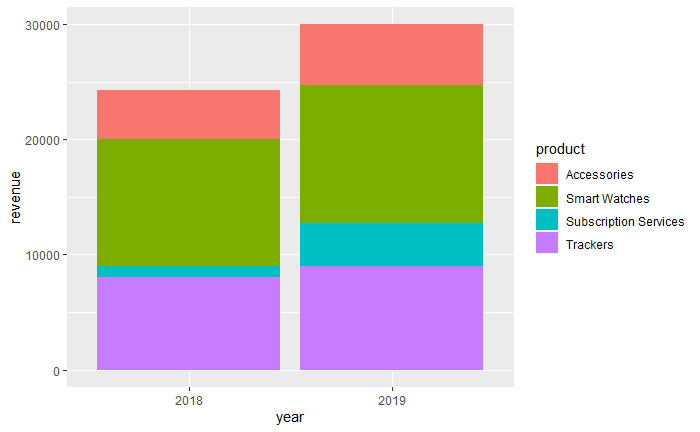

```r
revenue %>%
  ggplot(aes(x = year, y = revenue)) +
  geom_col(aes(fill = product))
```

## Question 2.

Make a line chart showing monthly sales of the “flagship product” - the ‘KwikBit Unit 1’ - over the last year. This data is inside qb_monthly_sales, but you will need to use filter() or subset() (base R).

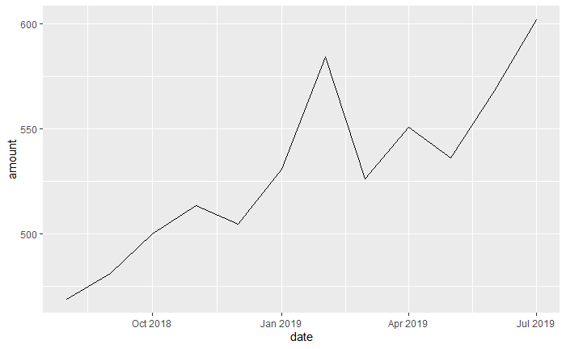

```r
monthtly_sales %>%
  filter(cashflow == "Kwikbit Unit 1 Sales") %>% #as.numeric(format(date, "%Y")) == 2019  &
  ggplot(aes(x = date,
             y = amount)) +
  geom_line()
```

## Question 3.

Make a line chart showing monthly revenue and costs over the last year. This data is also in qb_monthly_sales.

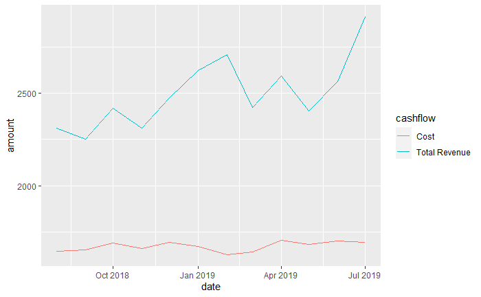

## Question 4.

Show annual sales of personal fitness trackers over the last 5 years broken down by company as a ribbon plot (use geom_area). This data is in qb_competitors.

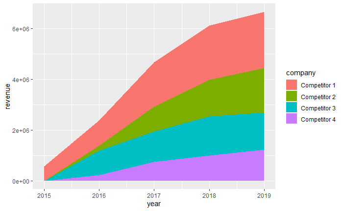

```r
competitors %>%
  ggplot(aes(x = year,
             y = revenue,
             fill = company)) +
  geom_area()
```

## Question 5.

Now show the sales from the four competitors as a line graph. Include an extra layer that shows the data points used to make the lines.

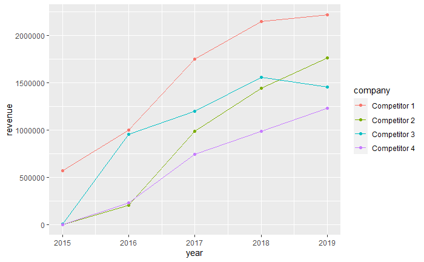

```r
competitors %>%
  ggplot(aes(x = year,
             y = revenue,
             colour = company)) +
  geom_line() +
  geom_point()
```

## Question 6.

Now the company wants to compare the number of steps that their device counts vs. their competitors. Make a line graph of the number of steps throughout time, and use faceting to compare between companies and people. The data for this is in qb_device_data.

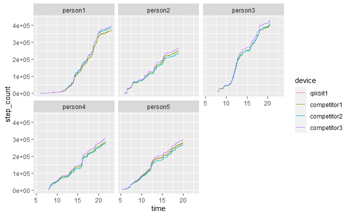

# Part 2

Question 1. Take the plots that you produced in part one and now polish them by:

Adding appropriate labels Changing the scales and coordinates when appropriate. Applying a unified theme, which is described below: Graphs should have white backgrounds, and use colour sparingly. There should be faint grid lines. Font sizes should be ~12pt although titles should be slightly larger and axis labels can be slightly smaller. All plots should use colours from the following company colour scheme.

col_scheme <- c(“#E89FE9”, “#50434F”, “#B6A7B5”, “#F9A472”, “#BD7040”)

```r
theme_bw
```

[output not shown]

## Question 1.

Take the data in the dataset qb_revenue_breakdown and make a stacked bar chart showing the sources of revenue across the two years in the dataset.

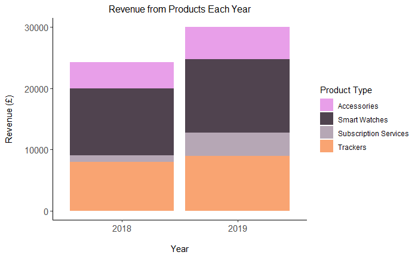

## Question 2.

Make a line chart showing monthly sales of the “flagship product” - the ‘KwikBit Unit 1’ - over the last year. This data is inside qb_monthly_sales, but you will need to use filter() or subset() (base R).

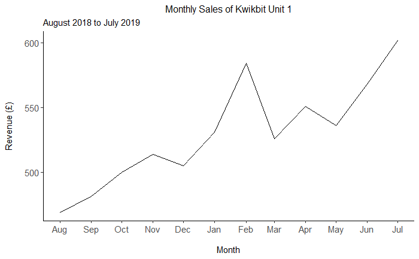

## Question 3.

Make a line chart showing monthly revenue and costs over the last year. This data is also in qb_monthly_sales.

[figure not shown]

## Question 4.

Show annual sales of personal fitness trackers over the last 5 years broken down by company as a ribbon plot (use geom_area). This data is in qb_competitors.

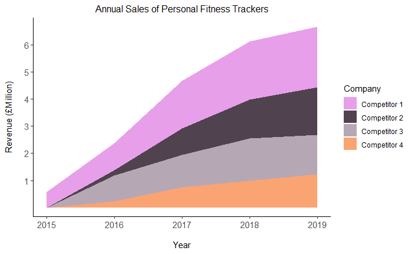

## Question 5.

Now show the sales from the four competitors as a line graph. Include an extra layer that shows the data points used to make the lines.

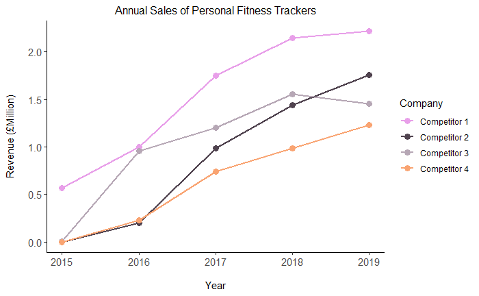

## Question 6.

Now the company wants to compare the number of steps that their device counts vs. their competitors. Make a line graph of the number of steps throughout time, and use faceting to compare between companies and people. The data for this is in qb_device_data.

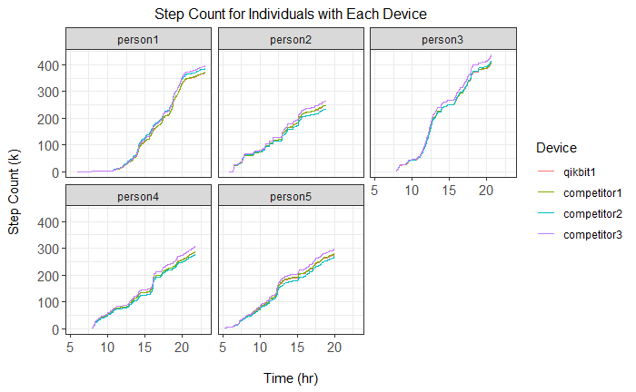